# CMSC 320 final

```
                               An Evaluation on the Causes and Health Effects of Obesity
```

Robert Zhang

Introduction: It is well known that obesity has a large number of well known negative health effects such as heart disease, diabetes, high blood pressure, liver disease, sleep apnea, and certain cancers. The causes of obesity have been linked to diet, sedentary lifestyle, sleep, and environment. Therefore, the increased rates of obesity that do do not seem to be stopping any time soon are a cause for concern. Data collection can be used to identify the size of the problem in this case being obesity and can help determine if a certain programme is working.

Purpose: The purpose of this tutorial is to showcase how you can use pythons various features and libraries in order for the reader to have a better understanding on how to obtain data, and use that data to create linear models. It should be noted that this tutorial is meant to just be a simple example of what you can do and there are honestly plenty of flaws in the methodology. For one since we are going to be do doing it based on mostly the means and averages by State then that really means we only have 50 observations which is just too few. Also in some cases, for some of the independent variables that we will be using such as age the age range is just too small from only 31 to 45 simply because there just was not a table for each year age, only large brackets.

```python
# data collection
import numpy as np
import pandas as pd
import re
import requests
from bs4 import BeautifulSoup


# plotting graphs and the map of every country
import matplotlib.pyplot as plt
import plotly.express as px

# machine learning and filling in missing data
from sklearn import linear_model
from sklearn.impute import KNNImputer
from sklearn.ensemble import RandomForestClassifier
from sklearn.linear_model import LinearRegression
from sklearn.model_selection import GridSearchCV
from sklearn import preprocessing
from sklearn.preprocessing import StandardScaler
from sklearn.linear_model import Ridge
import seaborn as sns
import statsmodels.formula.api as sm
```

Part 1: Data collection In this part of the project we are simply just collecting the data. There will be one group of data about the percentage of people who are normal, overweight, or obese. Then there will be another data set about obesity rates by states.

```python
obesity_in_adults = pd.read_csv('obesityover20.csv')
```

```python
obesity_in_adults = obesity_in_adults[["PANEL", "YEAR", "STUB_LABEL", "ESTIMATE"]]
```

```python
obesity_in_adults
```

|  | PANEL | YEAR | STUB_LABEL | ESTIMATE |
| --- | --- | --- | --- | --- |
| 0 | Normal weight (BMI from 18.5 to 24.9) | 1988-1994 | 20 years and over | 41.6 |
| 1 | Normal weight (BMI from 18.5 to 24.9) | 1999-2002 | 20 years and over | 33.0 |
| 2 | Normal weight (BMI from 18.5 to 24.9) | 2001-2004 | 20 years and over | 32.3 |
| 3 | Normal weight (BMI from 18.5 to 24.9) | 2003-2006 | 20 years and over | 31.6 |
| 4 | Normal weight (BMI from 18.5 to 24.9) | 2005-2008 | 20 years and over | 30.8 |
| ... | ... | ... | ... | ... |
| 3355 | Grade 3 obesity (BMI greater than or equal to ... | 2007-2010 | Female: 75 years and over | 3.4 |
| 3356 | Grade 3 obesity (BMI greater than or equal to ... | 2009-2012 | Female: 75 years and over | 4.1 |
| 3357 | Grade 3 obesity (BMI greater than or equal to ... | 2011-2014 | Female: 75 years and over | 3.3 |
| 3358 | Grade 3 obesity (BMI greater than or equal to ... | 2013-2016 | Female: 75 years and over | 3.4 |
| 3359 | Grade 3 obesity (BMI greater than or equal to ... | 2015-2018 | Female: 75 years and over | 5.1 |

3360 rows × 4 columns

One issue in pandas and data collection in general are missing values, in this case the missing values are represented as Nan. There are many methods to deal with missing values such as replacing all missing values with zero, dropping variables, and just dropping those observations. Each have their upsides and downsides. In this case we will just replace Nan values with zeros.

The first step is of course, to determine if there are any nan values which is what is being done below here.

```python
obesity_in_adults.isnull().any().any()
```

```
True
```

Next we will visualize the data using pyplot. However, in this case we will simply just plot the people that have a healthy BMI range. In order to do this we just want only the normal weights. A downtrend should be expected. The year looks a little bit messy so that will need to be cleaned up, in this case we will just simply keep only the starting year then since it will not effect the data too much.

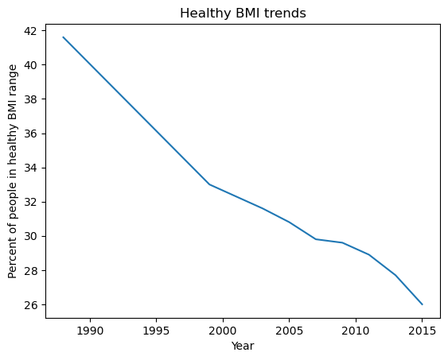

```python
normal_weights = obesity_in_adults[0:10].copy()
normal_weights['YEAR'] = normal_weights['YEAR'].str.split('-').str[0].astype(int)
plt.plot(normal_weights['YEAR'], normal_weights['ESTIMATE'])
plt.title('Healthy BMI trends')
plt.xlabel('Year')
plt.ylabel('Percent of people in healthy BMI range')
```

Part 2: Visualizing data For this part we will gather some data to visualize the effects that certain factors can increase the risk of obesity. These factors are race and income levels. We will now create a dataframe for each factor(or in this case the independent variable) and then merge them together. Here, the income are also in a certain range and makes the X axis of the scatterplot that we plan to plot a little bit messy so we will just replace that with the mean of that of range. For example 15000- 25000 becomes 20000. Since there is only one state with no data which is Florida we will just replace that line with zeros as well.

```python
income_df = pd.read_csv('income.csv')
income_df.rename(columns={
    '$15,000 to &lt; $25,000': '20000',
    '$25,000 to &lt; $35,000': '30000',
    'Less than $15,000': '15000',
    '$35,000 to &lt; $50,000': '42500',
    '$50,000 to &lt; $100,000': '75000',
    '$100,000 to &lt; $200,000': '150000'
}, inplace=True)
```

```python
income_df.columns
new_order = ['STATE','15000', '20000', '30000', '75000', '42500', '150000']
income_df = income_df.reindex(columns=new_order)
```

```python
income_df.head()
```

|  | STATE | 15000 | 20000 | 30000 | 75000 | 42500 | 150000 |
| --- | --- | --- | --- | --- | --- | --- | --- |
| 0 | Kentucky | 43.8% | 48.2% | 56.3% | 47.8% | 44.2% | 39.3% |
| 1 | West Virginia | 41.7% | 43.9% | 49.4% | 44.3% | 41.2% | 42.1% |
| 2 | North Carolina | 46.8% | 49.1% | 49.1% | 39.1% | 44.7% | 38.7% |
| 3 | South Dakota | 41.7% | 49.3% | 37.2% | 44.4% | 42.3% | 41.7% |
| 4 | Louisiana | 47.3% | 35.3% | 38.2% | 41.5% | 53.3% | 39.2% |

```python
income_df.fillna(0, inplace= True)
income_df = income_df.replace('%', '', regex= True)
income_df[['20000', '30000', '15000', '75000', '42500', '150000']] = income_df[['20000', '30000', '15000', '75000', '42500', '150000']].apply(pd.to_numeric)
```

Now we just need to melt the data in order to make the data more plottable.

```python
melted_income_df = pd.melt(income_df, id_vars=["STATE"], var_name="Income Level", value_name="Percentage")
melted_income_df
```

|  | STATE | Income Level | Percentage |
| --- | --- | --- | --- |
| 0 | Kentucky | 15000 | 43.8 |
| 1 | West Virginia | 15000 | 41.7 |
| 2 | North Carolina | 15000 | 46.8 |
| 3 | South Dakota | 15000 | 41.7 |
| 4 | Louisiana | 15000 | 47.3 |
| ... | ... | ... | ... |
| 301 | New Jersey | 150000 | 26.4 |
| 302 | California | 150000 | 31.0 |
| 303 | Hawaii | 150000 | 27.0 |
| 304 | Colorado | 150000 | 28.0 |
| 305 | Florida | 150000 | 0.0 |

306 rows × 3 columns

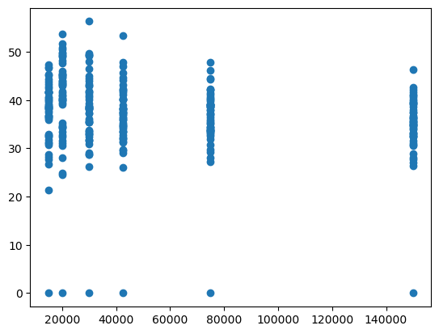

```python
melted_income_df.rename(columns={'Income Level': 'Income_Level', 'Percentage': 'Percentage'}, inplace=True)
melted_income_df['Income_Level'] = melted_income_df['Income_Level'].apply(pd.to_numeric)
plt.scatter(melted_income_df['Income_Level'], melted_income_df['Percentage'])
```

Hmm it seems like this plot does not tell us anything it seems we may need to use a violin plot.

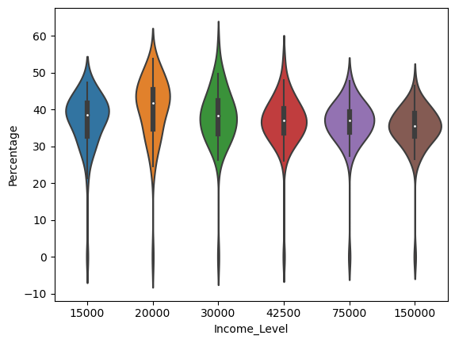

```python
sns.violinplot(x = "Income_Level", y = "Percentage", data = melted_income_df)
```

```python
income_regression = sm.ols(formula = 'Income_Level ~ Percentage', data = melted_income_df).fit()
```

```python
print(income_regression.summary())
```

```
                            OLS Regression Results
==============================================================================
Dep. Variable:           Income_Level   R-squared:                       0.026
Model:                            OLS   Adj. R-squared:                  0.023
Method:                 Least Squares   F-statistic:                     8.155
Date:                Sat, 18 May 2024   Prob (F-statistic):            0.00459
Time:                        22:32:26   Log-Likelihood:                -3719.5
No. Observations:                 306   AIC:                             7443.
Df Residuals:                     304   BIC:                             7450.
Df Model:                           1
Covariance Type:            nonrobust
==============================================================================
                 coef    std err          t      P>|t|      [0.025      0.975]
------------------------------------------------------------------------------
Intercept   9.117e+04   1.28e+04      7.126      0.000     6.6e+04    1.16e+05
Percentage  -961.7575    336.783     -2.856      0.005   -1624.478    -299.037
==============================================================================
Omnibus:                       46.750   Durbin-Watson:                   0.077
Prob(Omnibus):                  0.000   Jarque-Bera (JB):               65.984
Skew:                           1.137   Prob(JB):                     4.70e-15
Kurtosis:                       3.011   Cond. No.                         184.
==============================================================================

Notes:
[1] Standard Errors assume that the covariance matrix of the errors is correctly specified.
```

Ok well all of that should give an idea on the basic idea of the linear regression model, now we will do the multivariate version with more independent variables. The first variable needed is income level, however the previous income level data is not necessarily the format we would like so lets just get the median income level instead. Another factor that is commonly accept as a contributing factor is added sugar intake so therefore data on sugary beverages consumed daily could be an indicator, and sadly the data on sugar per state is paywalled. However the most common source of added sugar according to the CDC is beverages so this will be the next best thing. There is also the fact that college educated adults have on average less BMI than adults who did not recieve a college education so we will include this in our model as well. The last two factors to be included are age and physical activity.

```python
obesity_by_state_df = pd.read_csv('obesity.csv')
obesity_by_state_df.rename(columns = {'Row Labels' : 'State', 'Sum of Data_Value' : 'Obesity_Prevalence'}, inplace = True)
obesity_by_state_df['Obesity_Prevalence'] = pd.to_numeric(obesity_by_state_df['Obesity_Prevalence'], errors='coerce')

obesity_by_state_df.head()
```

|  | State | Obesity_Prevalence |
| --- | --- | --- |
| 0 | Alabama | 40.4 |
| 1 | Alaska | 33.4 |
| 2 | Arizona | 31.4 |
| 3 | Arkansas | 38.9 |
| 4 | California | 27.6 |

```python
median_income_df = pd.read_csv('med.csv')
```

```python
median_income_df = median_income_df[['State','Value (Dollars)']]
median_income_df.rename(columns = {'Value (Dollars)': 'Value_Dollars'} , inplace = True)
median_income_df.head()
```

|  | State | Value_Dollars |
| --- | --- | --- |
| 0 | Mississippi | 802 |
| 1 | Arkansas | 673 |
| 2 | West Virginia | 845 |
| 3 | New Mexico | 533 |
| 4 | Louisiana | 93 |

```python
url = "https://www.cdc.gov/pcd/issues/2021/20_0434a.htm#1"
response = requests.get(url)
soup = BeautifulSoup(response.content, 'html.parser')
table = soup.find('table')
sugar_df = pd.read_html(str(table))[0]
sugar_df.head()
sugar_df.rename(columns = {'Prevalence %' : 'Sugary_Beverage_Daily_Prevalence'}, inplace = True)
sugar_df['Sugary_Beverage_Daily_Prevalence'] = sugar_df['Sugary_Beverage_Daily_Prevalence'].astype(float)
sugar_df.head()
```

|  | State | Sugary_Beverage_Daily_Prevalence |
| --- | --- | --- |
| 0 | Alabama | 65.0 |
| 1 | Alaska | 44.5 |
| 2 | Arizona | 64.5 |
| 3 | Arkansas | 74.2 |
| 4 | California | 62.7 |

```python
college_educated_df = pd.read_csv('college.csv')
college_educated_df = college_educated_df[['state', 'PercentBachelorsOrHigher']]
college_educated_df.rename(columns = {'state' : 'State'}, inplace = True)
college_educated_df.head()
```

|  | State | PercentBachelorsOrHigher |
| --- | --- | --- |
| 0 | Alabama | 26.2 |
| 1 | Alaska | 30.0 |
| 2 | Arizona | 30.3 |
| 3 | Arkansas | 23.8 |
| 4 | California | 34.7 |

```python
age_url = "https://www.statsamerica.org/sip/rank_list.aspx?rank_label=pop46"
age_response = requests.get(age_url)
age_soup = BeautifulSoup(age_response.content, 'html.parser')
age_table = age_soup.find('table')
age_df = pd.read_html(str(age_table))[0]
age_df = age_df[['State', 'Population']]
age_df.rename(columns = {'Population' : 'Average_Age'} , inplace = True)
age_df.head()
```

|  | State | Average_Age |
| --- | --- | --- |
| 0 | Maine | 44.8 |
| 1 | New Hampshire | 43.3 |
| 2 | Vermont | 43.2 |
| 3 | West Virginia | 42.8 |
| 4 | Florida | 42.7 |

```python
physical_activity_df = pd.read_csv('physical_activity.csv')
physical_activity_df = physical_activity_df[['State', 'Prevalence']]
physical_activity_df.rename(columns = {'Prevalence' : 'Sedentary_Life_Prevalence'} , inplace = True)
physical_activity_df['Sedentary_Life_Prevalence'] = pd.to_numeric(physical_activity_df['Sedentary_Life_Prevalence'], errors='coerce')
physical_activity_df.head()
```

|  | State | Sedentary_Life_Prevalence |
| --- | --- | --- |
| 0 | Alabama | 30.7 |
| 1 | Alaska | 20.8 |
| 2 | Arizona | 23.3 |
| 3 | Arkansas | 31.1 |
| 4 | California | 21.2 |

Now we got the data we needed. Next we merge the data together in one dataframe. We do this by using the pd.join function. There will also most likely be missing data from this which will also needed to be handled. In order to decide what to do with the missing data we need to first obtain where we are missing the data. Well the first thing to notice here is that there is a state for the United States in the dataframes. This can just be discarded then since the data avaliable there is just the average number of people in the States who are educated. The next rows that have missing data are just some US territories such as Guam and Puerto Rico, and while these actually are unique observations there is only the percentage of people who are sedentary so we can just discard those. The Florida case is a little more interesting, the simplest way would be to just set it to zero like above, but another method would be to set that data point to the mean of the column in order to check what difference there would be between the two. Also the sedentary lifestyle preference for New Jersey will be set to the mean as well.

```python
frame_list = [obesity_by_state_df, median_income_df, sugar_df, college_educated_df, age_df, physical_activity_df]
for i in frame_list:
    i["State"] = i["State"].astype(str)
combined_obesity = frame_list[0]
for i in frame_list[1:]:
    combined_obesity = pd.merge(combined_obesity, i, on=['State'], how = 'outer')
combined_obesity.head()
```

|  | State | Obesity_Prevalence | Value_Dollars | Sugary_Beverage_Daily_Prevalence | PercentBachelorsOrHigher | Average_Age | Sedentary_Life_Prevalence |
| --- | --- | --- | --- | --- | --- | --- | --- |
| 0 | Alabama | 40.4 | 878.0 | 65.0 | 26.2 | 39.4 | 30.7 |
| 1 | Alaska | 33.4 | 658.0 | 44.5 | 30.0 | 35.8 | 20.8 |
| 2 | Arizona | 31.4 | 845.0 | 64.5 | 30.3 | 38.7 | 23.3 |
| 3 | Arkansas | 38.9 | 673.0 | 74.2 | 23.8 | 38.6 | 31.1 |
| 4 | California | 27.6 | 971.0 | 62.7 | 34.7 | 37.8 | 21.2 |

```python
combined_obesity = combined_obesity[combined_obesity['State'] != 'United States']
combined_obesity = combined_obesity[combined_obesity['State'] != 'Guam']
combined_obesity = combined_obesity[combined_obesity['State'] != 'Puerto Rico']
```

```python
combined_obesity['Obesity_Prevalence'].fillna(combined_obesity['Obesity_Prevalence'].mean(), inplace = True)
combined_obesity['Sedentary_Life_Prevalence'].fillna(combined_obesity['Sedentary_Life_Prevalence'].mean(), inplace = True)
```

Ok now that we have comblined all the data frames into one convenient package it is now time to create the initial linear model. Keep in mind that there will most likely still be issues with the model and we will have to do some checks.

```python
Starting_Model = sm.ols(formula = 'Obesity_Prevalence ~ Value_Dollars + Sugary_Beverage_Daily_Prevalence + PercentBachelorsOrHigher + Average_Age + Sedentary_Life_Prevalence', data = combined_obesity).fit()
print(Starting_Model.summary())
```

```
                            OLS Regression Results
==============================================================================
Dep. Variable:     Obesity_Prevalence   R-squared:                       0.784
Model:                            OLS   Adj. R-squared:                  0.760
Method:                 Least Squares   F-statistic:                     32.70
Date:                Sat, 18 May 2024   Prob (F-statistic):           6.39e-14
Time:                        22:32:27   Log-Likelihood:                -104.11
No. Observations:                  51   AIC:                             220.2
Df Residuals:                      45   BIC:                             231.8
Df Model:                           5
Covariance Type:            nonrobust
====================================================================================================
                                       coef    std err          t      P>|t|      [0.025      0.975]
----------------------------------------------------------------------------------------------------
Intercept                           36.2137      6.296      5.752      0.000      23.533      48.895
Value_Dollars                        0.0002      0.001      0.162      0.872      -0.002       0.002
Sugary_Beverage_Daily_Prevalence    -0.1407      0.049     -2.880      0.006      -0.239      -0.042
PercentBachelorsOrHigher            -0.2114      0.061     -3.465      0.001      -0.334      -0.089
Average_Age                         -0.1241      0.133     -0.930      0.357      -0.393       0.145
Sedentary_Life_Prevalence            0.7149      0.112      6.358      0.000       0.488       0.941
==============================================================================
Omnibus:                        0.952   Durbin-Watson:                   2.600
Prob(Omnibus):                  0.621   Jarque-Bera (JB):                0.317
Skew:                           0.069   Prob(JB):                        0.854
Kurtosis:                       3.360   Cond. No.                     1.38e+04
==============================================================================

Notes:
[1] Standard Errors assume that the covariance matrix of the errors is correctly specified.
[2] The condition number is large, 1.38e+04. This might indicate that there are
strong multicollinearity or other numerical problems.
```

Finally, as the notes say there probably are some multicollinearity issues.

```python
combined_obesity[['Obesity_Prevalence' , 'Value_Dollars' , 'Sugary_Beverage_Daily_Prevalence', \
                  'PercentBachelorsOrHigher', 'Average_Age','Sedentary_Life_Prevalence']].corr()
```

|  | Obesity_Prevalence | Value_Dollars | Sugary_Beverage_Daily_Prevalence | PercentBachelorsOrHigher | Average_Age | Sedentary_Life_Prevalence |
| --- | --- | --- | --- | --- | --- | --- |
| Obesity_Prevalence | 1.000000 | 0.081237 | -0.024944 | -0.761080 | -0.050721 | 0.787504 |
| Value_Dollars | 0.081237 | 1.000000 | -0.011807 | -0.136562 | -0.070029 | 0.024355 |
| Sugary_Beverage_Daily_Prevalence | -0.024944 | -0.011807 | 1.000000 | -0.017724 | 0.333175 | 0.348100 |
| PercentBachelorsOrHigher | -0.761080 | -0.136562 | -0.017724 | 1.000000 | -0.065226 | -0.655294 |
| Average_Age | -0.050721 | -0.070029 | 0.333175 | -0.065226 | 1.000000 | 0.115155 |
| Sedentary_Life_Prevalence | 0.787504 | 0.024355 | 0.348100 | -0.655294 | 0.115155 | 1.000000 |

In this case there is a strong correlation between percentage of bachelors and sedentary life. There are a few ways to address this collinearity though. Two of them are PCA or principal component analysis and ridge regression which we will both do later. Lets start with PCA then.

The first step to PCA is that we must center the data. This is done by subtracting the mean of each column.

```python
PCA_obesity_matrix = combined_obesity[['Obesity_Prevalence' , 'Value_Dollars' , 'Sugary_Beverage_Daily_Prevalence', \
                     'PercentBachelorsOrHigher', 'Average_Age','Sedentary_Life_Prevalence']]
```

```python
PCA_obesity_matrix = PCA_obesity_matrix - np.mean(PCA_obesity_matrix, axis=0)
```

The second step is to compute the covariance matrix.

```python
obesity_cov = PCA_obesity_matrix.cov()
obesity_cov
```

|  | Obesity_Prevalence | Value_Dollars | Sugary_Beverage_Daily_Prevalence | PercentBachelorsOrHigher | Average_Age | Sedentary_Life_Prevalence |
| --- | --- | --- | --- | --- | --- | --- |
| Obesity_Prevalence | 16.411700 | 94.027600 | -0.686380 | -20.016980 | -0.461700 | 11.846616 |
| Value_Dollars | 94.027600 | 81629.772549 | -22.912392 | -253.306078 | -44.956941 | 25.839520 |
| Sugary_Beverage_Daily_Prevalence | -0.686380 | -22.912392 | 46.135137 | -0.781573 | 5.084929 | 8.779800 |
| PercentBachelorsOrHigher | -20.016980 | -253.306078 | -0.781573 | 42.148525 | -0.951494 | -15.797628 |
| Average_Age | -0.461700 | -44.956941 | 5.084929 | -0.951494 | 5.048871 | 0.960828 |
| Sedentary_Life_Prevalence | 11.846616 | 25.839520 | 8.779800 | -15.797628 | 0.960828 | 13.788884 |

The third step is to find the eigenvalues and eigenvectors.

```python
evals, evectors = np.linalg.eig(obesity_cov)
```

The fourth step is to sort the eigen vectors with corresponding eigen values by biggest to smallest. We will take the two biggest eigenvectors.

```python
evals
```

```
array([8.16307069e+04, 6.14705207e+01, 4.71461657e+01, 7.80334374e+00,
       1.95587469e+00, 4.22289470e+00])
```

```python
evectors
```

```
array([[-1.15290367e-03,  4.32466543e-01, -1.74175326e-01,
        -5.60254544e-01,  6.81395198e-01,  6.67064133e-02],
       [-9.99994273e-01, -2.87646101e-03,  1.35669161e-03,
        -8.07880474e-04, -2.60744438e-04,  7.85975215e-04],
       [ 2.80820742e-04,  2.70818245e-01,  9.37607167e-01,
         6.93889754e-02,  1.39750831e-01, -1.52332123e-01],
       [ 3.10499389e-03, -7.56294845e-01,  2.74209394e-01,
        -5.73154526e-01,  6.49678671e-02,  1.41741808e-01],
       [ 5.50750656e-04,  4.28486006e-02,  1.08869482e-01,
         2.44331594e-01,  1.07885676e-01,  9.56542672e-01],
       [-3.17324980e-04,  4.07190370e-01,  5.92499831e-02,
        -5.41382790e-01, -7.07326005e-01,  1.93080133e-01]])
```

```python
index = np.argsort(evals)[::-1]
evals = evals[index]
evectors = evectors[:, index]
p_components = evals[:2] * evectors[:, :2]
p_components
```

```
array([[-9.41123415e+01,  2.65839436e+01],
       [-8.16302394e+04, -1.76817556e-01],
       [ 2.29235957e+01,  1.66473385e+01],
       [ 2.53462846e+02, -4.64898379e+01],
       [ 4.49581654e+01,  2.63392579e+00],
       [-2.59034624e+01,  2.50302041e+01]])
```

The last step is to transform the data and plot it.

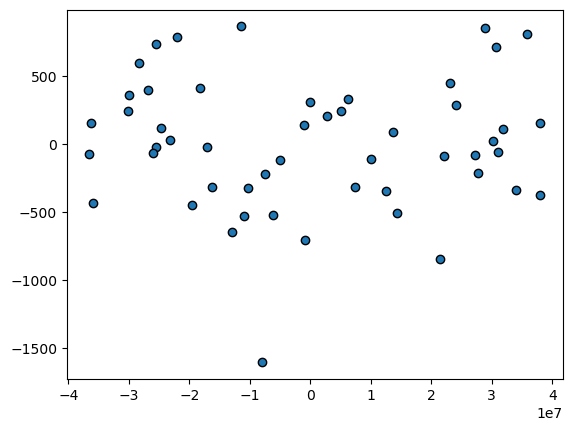

```python
Transformed_data = np.dot(PCA_obesity_matrix, p_components)
plt.scatter(Transformed_data.T[0], Transformed_data.T[1], edgecolor = 'k')
```

Lastly we will train this model using gradient descent. Since we have collinearity issues we will use a ridge gradient descent with a penalty variable. First we will split into training data and test data. The test data will be the first five rows and training data will be the rest.

```python
test_data = combined_obesity[['Obesity_Prevalence' , 'Value_Dollars' , 'Sugary_Beverage_Daily_Prevalence', \
                     'PercentBachelorsOrHigher', 'Average_Age','Sedentary_Life_Prevalence']].head()
training_data = combined_obesity[['Obesity_Prevalence' , 'Value_Dollars' , 'Sugary_Beverage_Daily_Prevalence', \
                     'PercentBachelorsOrHigher', 'Average_Age','Sedentary_Life_Prevalence']][5:]
```

Next we will need to square the independent training set data and put them together. First we need to standardized the training data. This will be our X in the grad_descent mathod. We will also square the dependent variable too. We will use cross validation to find the best alpha term here.

```python
mean =  np.mean(training_data, axis=0)
standard_deviation = np.std(training_data, axis=0)
training_data = (training_data - mean) / standard_deviation

test_mean =  np.mean(test_data, axis=0)
test_standard_deviation = np.std(test_data, axis=0)
test_data = (test_data - test_mean) / test_standard_deviation

stack = np.column_stack((training_data['Value_Dollars']**2, \
                        training_data['Sugary_Beverage_Daily_Prevalence']**2, \
                        training_data['PercentBachelorsOrHigher']**2, \
                        training_data['Average_Age']**2, \
                        training_data['Sedentary_Life_Prevalence']**2))
independent_term = training_data['Obesity_Prevalence']**2
r_alphas=np.arange(0.0001,0.01,0.0005)
hyper_params = {'alpha': r_alphas}

grid = GridSearchCV(Ridge(), param_grid = hyper_params, scoring = 'r2', cv=10)
grid.fit(stack, independent_term)
alpha = grid.best_params_['alpha']
best_ridge = grid.best_estimator_
coefficient = best_ridge.coef_ ** 2
T = 500
l2 = np.sqrt((np.sum(coefficient ** 2)))
alpha
```

```
0.009600000000000001
```

```python
def ridge_grad_descent(X, y, T, alpha, penalty):
    m, n = X.shape # m = #examples, n = #features
    theta = np.zeros(n) # initialize parameters
    f = np.zeros(T) # track loss over time
    for i in range(T):
        # loss for current parameter vector theta
        f[i] = 0.5 * np.linalg.norm(X.dot(theta) - y) ** 2 + penalty * (np.linalg.norm(theta)) ** 2
        # compute steepest ascent at f(theta)
        g = np.transpose(X).dot(X.dot(theta) - y) + 2 * penalty * theta
        # step down the gradient
        theta = theta - alpha * g
    return theta, f
```

```python
weight, loss = ridge_grad_descent(stack, independent_term, T, alpha, l2)
loss
```

```
array([5.77724402e+001, 3.35212936e+002, 3.16043046e+003, 3.10421545e+004,
       3.06161099e+005, 3.02085406e+006, 2.98076595e+007, 2.94122245e+008,
       2.90220480e+009, 2.86370488e+010, 2.82571571e+011, 2.78823049e+012,
       2.75124253e+013, 2.71474525e+014, 2.67873214e+015, 2.64319676e+016,
       2.60813279e+017, 2.57353397e+018, 2.53939413e+019, 2.50570718e+020,
       2.47246711e+021, 2.43966799e+022, 2.40730398e+023, 2.37536930e+024,
       2.34385826e+025, 2.31276524e+026, 2.28208469e+027, 2.25181114e+028,
       2.22193919e+029, 2.19246351e+030, 2.16337885e+031, 2.13468002e+032,
       2.10636190e+033, 2.07841944e+034, 2.05084766e+035, 2.02364164e+036,
       1.99679653e+037, 1.97030754e+038, 1.94416995e+039, 1.91837908e+040,
       1.89293036e+041, 1.86781923e+042, 1.84304122e+043, 1.81859191e+044,
       1.79446693e+045, 1.77066199e+046, 1.74717284e+047, 1.72399530e+048,
       1.70112522e+049, 1.67855852e+050, 1.65629120e+051, 1.63431926e+052,
       1.61263880e+053, 1.59124595e+054, 1.57013689e+055, 1.54930785e+056,
       1.52875513e+057, 1.50847506e+058, 1.48846401e+059, 1.46871843e+060,
       1.44923479e+061, 1.43000961e+062, 1.41103947e+063, 1.39232098e+064,
       1.37385081e+065, 1.35562565e+066, 1.33764227e+067, 1.31989745e+068,
       1.30238803e+069, 1.28511088e+070, 1.26806293e+071, 1.25124113e+072,
       1.23464249e+073, 1.21826404e+074, 1.20210286e+075, 1.18615607e+076,
       1.17042083e+077, 1.15489433e+078, 1.13957379e+079, 1.12445650e+080,
       1.10953975e+081, 1.09482088e+082, 1.08029726e+083, 1.06596632e+084,
       1.05182548e+085, 1.03787223e+086, 1.02410409e+087, 1.01051858e+088,
       9.97113302e+088, 9.83885852e+089, 9.70833875e+090, 9.57955041e+091,
       9.45247055e+092, 9.32707649e+093, 9.20334589e+094, 9.08125666e+095,
       8.96078703e+096, 8.84191553e+097, 8.72462094e+098, 8.60888235e+099,
       8.49467912e+100, 8.38199088e+101, 8.27079754e+102, 8.16107926e+103,
       8.05281647e+104, 7.94598987e+105, 7.84058040e+106, 7.73656927e+107,
       7.63393792e+108, 7.53266806e+109, 7.43274161e+110, 7.33414077e+111,
       7.23684793e+112, 7.14084576e+113, 7.04611713e+114, 6.95264514e+115,
       6.86041313e+116, 6.76940465e+117, 6.67960346e+118, 6.59099355e+119,
       6.50355912e+120, 6.41728457e+121, 6.33215452e+122, 6.24815378e+123,
       6.16526737e+124, 6.08348051e+125, 6.00277861e+126, 5.92314729e+127,
       5.84457234e+128, 5.76703974e+129, 5.69053566e+130, 5.61504647e+131,
       5.54055871e+132, 5.46705907e+133, 5.39453447e+134, 5.32297195e+135,
       5.25235877e+136, 5.18268232e+137, 5.11393019e+138, 5.04609010e+139,
       4.97914996e+140, 4.91309783e+141, 4.84792193e+142, 4.78361064e+143,
       4.72015249e+144, 4.65753616e+145, 4.59575047e+146, 4.53478442e+147,
       4.47462714e+148, 4.41526788e+149, 4.35669607e+150, 4.29890125e+151,
       4.24187313e+152, 4.18560153e+153, 4.13007641e+154, 4.07528787e+155,
       4.02122615e+156, 3.96788159e+157, 3.91524469e+158, 3.86330605e+159,
```

[output cut: 70 more lines]

```
                   inf,             inf,             inf,             inf,
                   inf,             inf,             inf,             inf,
                   inf,             inf,             inf,             inf,
                   inf,             inf,             inf,             inf,
                   inf,             inf,             inf,             inf,
                   inf,             inf,             inf,             inf,
                   inf,             inf,             inf,             inf,
                   inf,             inf,             inf,             inf,
                   inf,             inf,             inf,             inf,
                   inf,             inf,             inf,             inf,
                   inf,             inf,             inf,             inf,
                   inf,             inf,             inf,             inf,
                   inf,             inf,             inf,             inf,
                   inf,             inf,             inf,             inf,
                   inf,             inf,             inf,             inf])
```

hmm it seems the alpha value is probably too large.

```python
weight, loss = ridge_grad_descent(stack, independent_term, T, alpha/10, l2)
loss
```

```
array([57.77244022, 34.7614047 , 26.04049547, 22.38707531, 20.60219889,
       19.5615464 , 18.8584095 , 18.33672504, 17.92987088, 17.60461214,
       17.341295  , 17.12660332, 16.95072247, 16.80609027, 16.68675106,
       16.58796272, 16.50592651, 16.43758737, 16.38048078, 16.33261311,
       16.29236731, 16.25842827, 16.2297235 , 16.20537595, 16.18466634,
       16.16700311, 16.15189832, 16.13894831, 16.1278182 , 16.11822935,
       16.10994924, 16.1027833 , 16.09656825, 16.0911667 , 16.08646273,
       16.08235829, 16.07877023, 16.07562786, 16.07287094, 16.07044803,
       16.0683151 , 16.06643438, 16.06477342, 16.06330425, 16.06200275,
       16.06084809, 16.05982221, 16.05890945, 16.05809622, 16.05737066,
       16.05672247, 16.05614265, 16.05562331, 16.05515758, 16.05473941,
       16.05436349, 16.05402518, 16.05372035, 16.0534454 , 16.05319713,
       16.05297273, 16.05276968, 16.05258579, 16.05241909, 16.05226783,
       16.05213046, 16.05200561, 16.05189203, 16.05178863, 16.05169443,
       16.05160855, 16.05153019, 16.05145866, 16.05139331, 16.05133358,
       16.05127895, 16.05122896, 16.05118318, 16.05114125, 16.05110283,
       16.05106759, 16.05103528, 16.05100562, 16.0509784 , 16.0509534 ,
       16.05093044, 16.05090933, 16.05088993, 16.0508721 , 16.05085569,
       16.0508406 , 16.05082672, 16.05081394, 16.05080217, 16.05079134,
       16.05078136, 16.05077217, 16.0507637 , 16.0507559 , 16.05074871,
       16.05074209, 16.05073598, 16.05073035, 16.05072515, 16.05072037,
       16.05071595, 16.05071188, 16.05070812, 16.05070466, 16.05070146,
       16.05069851, 16.05069579, 16.05069328, 16.05069096, 16.05068882,
       16.05068685, 16.05068503, 16.05068335, 16.0506818 , 16.05068036,
       16.05067904, 16.05067782, 16.0506767 , 16.05067566, 16.05067469,
       16.05067381, 16.05067299, 16.05067223, 16.05067154, 16.05067089,
       16.0506703 , 16.05066975, 16.05066924, 16.05066877, 16.05066834,
       16.05066794, 16.05066757, 16.05066723, 16.05066692, 16.05066662,
       16.05066636, 16.05066611, 16.05066588, 16.05066567, 16.05066547,
       16.05066529, 16.05066513, 16.05066497, 16.05066483, 16.0506647 ,
       16.05066458, 16.05066447, 16.05066436, 16.05066427, 16.05066418,
       16.0506641 , 16.05066402, 16.05066395, 16.05066389, 16.05066383,
       16.05066378, 16.05066373, 16.05066368, 16.05066364, 16.0506636 ,
       16.05066356, 16.05066353, 16.05066349, 16.05066347, 16.05066344,
       16.05066341, 16.05066339, 16.05066337, 16.05066335, 16.05066333,
       16.05066332, 16.0506633 , 16.05066329, 16.05066327, 16.05066326,
       16.05066325, 16.05066324, 16.05066323, 16.05066322, 16.05066321,
       16.05066321, 16.0506632 , 16.05066319, 16.05066319, 16.05066318,
       16.05066318, 16.05066317, 16.05066317, 16.05066316, 16.05066316,
       16.05066316, 16.05066315, 16.05066315, 16.05066315, 16.05066315,
```

[output cut: 45 more lines]

```
       16.05066312, 16.05066312, 16.05066312, 16.05066312, 16.05066312,
       16.05066312, 16.05066312, 16.05066312, 16.05066312, 16.05066312,
       16.05066312, 16.05066312, 16.05066312, 16.05066312, 16.05066312,
       16.05066312, 16.05066312, 16.05066312, 16.05066312, 16.05066312,
       16.05066312, 16.05066312, 16.05066312, 16.05066312, 16.05066312,
       16.05066312, 16.05066312, 16.05066312, 16.05066312, 16.05066312,
       16.05066312, 16.05066312, 16.05066312, 16.05066312, 16.05066312,
       16.05066312, 16.05066312, 16.05066312, 16.05066312, 16.05066312,
       16.05066312, 16.05066312, 16.05066312, 16.05066312, 16.05066312,
       16.05066312, 16.05066312, 16.05066312, 16.05066312, 16.05066312,
       16.05066312, 16.05066312, 16.05066312, 16.05066312, 16.05066312,
       16.05066312, 16.05066312, 16.05066312, 16.05066312, 16.05066312,
       16.05066312, 16.05066312, 16.05066312, 16.05066312, 16.05066312,
       16.05066312, 16.05066312, 16.05066312, 16.05066312, 16.05066312,
       16.05066312, 16.05066312, 16.05066312, 16.05066312, 16.05066312])
```

Extra resources: Here are the websites where the data was obtained: \ https://www.cdc.gov/nutrition/data-statistics/sugar-sweetened-beverages-intake.html \ https://data.census.gov/all?q=median+household+income+by+state https://www.visualcapitalist.com/mapping-the-u-s-median-age-by-state/

Here are also some websites to help better understand the concepts: Linear regression: https://www.ibm.com/topics/linear-regression#:~:text=IBM-,What%20is%20linear%20regression%3F,is%20called%20the%20independent%20variable

Ridge gradient descent: https://machinelearningcompass.com/machine_learning_models/ridge_regression/